# **Problem Statement**

## Business Context

A sales forecast is a prediction of future sales revenue based on historical data, industry trends, and the status of the current sales pipeline. Businesses use the sales forecast to estimate weekly, monthly, quarterly, and annual sales totals. A company needs to make an accurate sales forecast as it adds value across an organization and helps the different verticals to chalk out their future course of action.

Forecasting helps an organization plan its sales operations by region and provides valuable insights to the supply chain team regarding the procurement of goods and materials. An accurate sales forecast process has many benefits which include improved decision-making about the future and reduction of sales pipeline and forecast risks. Moreover, it helps to reduce the time spent in planning territory coverage and establish benchmarks that can be used to assess trends in the future.

## Objective

SuperKart is a retail chain operating supermarkets and food marts across various tier cities, offering a wide range of products. To optimize its inventory management and make informed decisions around regional sales strategies, SuperKart wants to accurately forecast the sales revenue of its outlets for the upcoming quarter.

To operationalize these insights at scale, the company has partnered with a data science firm—not just to build a predictive model based on historical sales data, but to develop and deploy a robust forecasting solution that can be integrated into SuperKart’s decision-making systems and used across its network of stores.

## Data Description

The data contains the different attributes of the various products and stores.The detailed data dictionary is given below.

- **Product_Id** - unique identifier of each product, each identifier having two letters at the beginning followed by a number.
- **Product_Weight** - weight of each product
- **Product_Sugar_Content** - sugar content of each product like low sugar, regular and no sugar
- **Product_Allocated_Area** - ratio of the allocated display area of each product to the total display area of all the products in a store
- **Product_Type** - broad category for each product like meat, snack foods, hard drinks, dairy, canned, soft drinks, health and hygiene, baking goods, bread, breakfast, frozen foods, fruits and vegetables, household, seafood, starchy foods, others
- **Product_MRP** - maximum retail price of each product
- **Store_Id** - unique identifier of each store
- **Store_Establishment_Year** - year in which the store was established
- **Store_Size** - size of the store depending on sq. feet like high, medium and low
- **Store_Location_City_Type** - type of city in which the store is located like Tier 1, Tier 2 and Tier 3. Tier 1 consists of cities where the standard of living is comparatively higher than its Tier 2 and Tier 3 counterparts.
- **Store_Type** - type of store depending on the products that are being sold there like Departmental Store, Supermarket Type 1, Supermarket Type 2 and Food Mart
- **Product_Store_Sales_Total** - total revenue generated by the sale of that particular product in that particular store

# **Installing and Importing the necessary libraries**

```python
#Installing the libraries with the specified versions
!pip install numpy==2.0.2 pandas==2.2.2 scikit-learn==1.6.1 matplotlib==3.10.0 seaborn==0.13.2 joblib==1.4.2 xgboost==2.1.4 requests==2.32.4 huggingface_hub==0.34.0 -q
```

[output not shown]

**Note:**

- After running the above cell, kindly restart the notebook kernel (for Jupyter Notebook) or runtime (for Google Colab) and run all cells sequentially from the next cell.
- On executing the above line of code, you might see a warning regarding package dependencies. This error message can be ignored as the above code ensures that all necessary libraries and their dependencies are maintained to successfully execute the code in this notebook.

```python
#import the neccessary libraries required to successfully run the notebook
import warnings
warnings.filterwarnings("ignore")

# Libraries to help with reading and manipulating data
import numpy as np
import pandas as pd

# For splitting the dataset
from sklearn.model_selection import train_test_split

# Libaries to help with data visualization
import matplotlib.pyplot as plt
import seaborn as sns

# Removes the limit for the number of displayed columns
pd.set_option("display.max_columns", None)
# Sets the limit for the number of displayed rows
pd.set_option("display.max_rows", 100)


# Libraries different ensemble classifiers
from sklearn.ensemble import (
    BaggingRegressor,
    RandomForestRegressor,
    AdaBoostRegressor,
    GradientBoostingRegressor,
)
from xgboost import XGBRegressor
from sklearn.tree import DecisionTreeRegressor

# Libraries to get different metric scores
from sklearn.metrics import (
    confusion_matrix,
    accuracy_score,
    precision_score,
    recall_score,
    f1_score,
    mean_squared_error,
    mean_absolute_error,
    r2_score,
    mean_absolute_percentage_error
)

# To create the pipeline
from sklearn.compose import make_column_transformer
from sklearn.pipeline import make_pipeline,Pipeline

# To tune different models and standardize
from sklearn.model_selection import GridSearchCV
from sklearn.preprocessing import StandardScaler,OneHotEncoder

# To serialize the model
import joblib

# os related functionalities
import os

# API request
import requests

# for hugging face space authentication to upload files
from huggingface_hub import login, HfApi
```

#### Observation -

All the required files have been imported successfully without throwing any error.

# **Loading the dataset**

```python
#Loading the dataset
superkart = pd.read_csv("SuperKart.csv")
```

```python
#creating the copy of the dataset
kart = superkart.copy()
```

#### Observation -

CSV files have been loaded successfully without any errors.

# **Data Overview**

```python
#checking the shape of the superkart file
superkart.shape
```

```
(8763, 12)
```

#### Observation -

Superkart dataset has 8763 rows and 12 columns.

```python
#checking top 5 rows of the superkart file
superkart.head()
```

|  | Product_Id | Product_Weight | Product_Sugar_Content | Product_Allocated_Area | Product_Type | Product_MRP | Store_Id | Store_Establishment_Year | Store_Size | Store_Location_City_Type | Store_Type | Product_Store_Sales_Total |
| --- | --- | --- | --- | --- | --- | --- | --- | --- | --- | --- | --- | --- |
| 0 | FD6114 | 12.66 | Low Sugar | 0.027 | Frozen Foods | 117.08 | OUT004 | 2009 | Medium | Tier 2 | Supermarket Type2 | 2842.40 |
| 1 | FD7839 | 16.54 | Low Sugar | 0.144 | Dairy | 171.43 | OUT003 | 1999 | Medium | Tier 1 | Departmental Store | 4830.02 |
| 2 | FD5075 | 14.28 | Regular | 0.031 | Canned | 162.08 | OUT001 | 1987 | High | Tier 2 | Supermarket Type1 | 4130.16 |
| 3 | FD8233 | 12.10 | Low Sugar | 0.112 | Baking Goods | 186.31 | OUT001 | 1987 | High | Tier 2 | Supermarket Type1 | 4132.18 |
| 4 | NC1180 | 9.57 | No Sugar | 0.010 | Health and Hygiene | 123.67 | OUT002 | 1998 | Small | Tier 3 | Food Mart | 2279.36 |

```python
#checking the last 5 rows of the superkart file
superkart.tail()
```

|  | Product_Id | Product_Weight | Product_Sugar_Content | Product_Allocated_Area | Product_Type | Product_MRP | Store_Id | Store_Establishment_Year | Store_Size | Store_Location_City_Type | Store_Type | Product_Store_Sales_Total |
| --- | --- | --- | --- | --- | --- | --- | --- | --- | --- | --- | --- | --- |
| 8758 | NC7546 | 14.80 | No Sugar | 0.016 | Health and Hygiene | 140.53 | OUT004 | 2009 | Medium | Tier 2 | Supermarket Type2 | 3806.53 |
| 8759 | NC584 | 14.06 | No Sugar | 0.142 | Household | 144.51 | OUT004 | 2009 | Medium | Tier 2 | Supermarket Type2 | 5020.74 |
| 8760 | NC2471 | 13.48 | No Sugar | 0.017 | Health and Hygiene | 88.58 | OUT001 | 1987 | High | Tier 2 | Supermarket Type1 | 2443.42 |
| 8761 | NC7187 | 13.89 | No Sugar | 0.193 | Household | 168.44 | OUT001 | 1987 | High | Tier 2 | Supermarket Type1 | 4171.82 |
| 8762 | FD306 | 14.73 | Low Sugar | 0.177 | Snack Foods | 224.93 | OUT002 | 1998 | Small | Tier 3 | Food Mart | 2186.08 |

#### Observation -

Dataset has been loaded properly and upon observation, everything looks good.

```python
#checking the data info of the superkart file
superkart.info()
```

```
<class 'pandas.core.frame.DataFrame'>
RangeIndex: 8763 entries, 0 to 8762
Data columns (total 12 columns):
 #   Column                     Non-Null Count  Dtype
---  ------                     --------------  -----
 0   Product_Id                 8763 non-null   object
 1   Product_Weight             8763 non-null   float64
 2   Product_Sugar_Content      8763 non-null   object
 3   Product_Allocated_Area     8763 non-null   float64
 4   Product_Type               8763 non-null   object
 5   Product_MRP                8763 non-null   float64
 6   Store_Id                   8763 non-null   object
 7   Store_Establishment_Year   8763 non-null   int64
 8   Store_Size                 8763 non-null   object
 9   Store_Location_City_Type   8763 non-null   object
 10  Store_Type                 8763 non-null   object
 11  Product_Store_Sales_Total  8763 non-null   float64
dtypes: float64(4), int64(1), object(7)
memory usage: 821.7+ KB
```

#### Observation -

- There are 7 columns where datatype is object.
- There are 4 float type and 1 is integer type.

```python
#checking the missing values in the superkart file
superkart.isnull().sum()
```

|  | 0 |
| --- | --- |
| Product_Id | 0 |
| Product_Weight | 0 |
| Product_Sugar_Content | 0 |
| Product_Allocated_Area | 0 |
| Product_Type | 0 |
| Product_MRP | 0 |
| Store_Id | 0 |
| Store_Establishment_Year | 0 |
| Store_Size | 0 |
| Store_Location_City_Type | 0 |
| Store_Type | 0 |
| Product_Store_Sales_Total | 0 |

**dtype:** int64

#### Observation -

There are no missing values in the dataset, so we dont have to do missing value treatment.

```python
#checking the duplicate values in superkart file
superkart.duplicated().sum()
```

```
np.int64(0)
```

#### Observation -

There are no duplicates as well, so no treatment for duplicates.

```python
#checking the statistical summary of the superkart
superkart.describe()
```

|  | Product_Weight | Product_Allocated_Area | Product_MRP | Store_Establishment_Year | Product_Store_Sales_Total |
| --- | --- | --- | --- | --- | --- |
| count | 8763.000000 | 8763.000000 | 8763.000000 | 8763.000000 | 8763.000000 |
| mean | 12.653792 | 0.068786 | 147.032539 | 2002.032751 | 3464.003640 |
| std | 2.217320 | 0.048204 | 30.694110 | 8.388381 | 1065.630494 |
| min | 4.000000 | 0.004000 | 31.000000 | 1987.000000 | 33.000000 |
| 25% | 11.150000 | 0.031000 | 126.160000 | 1998.000000 | 2761.715000 |
| 50% | 12.660000 | 0.056000 | 146.740000 | 2009.000000 | 3452.340000 |
| 75% | 14.180000 | 0.096000 | 167.585000 | 2009.000000 | 4145.165000 |
| max | 22.000000 | 0.298000 | 266.000000 | 2009.000000 | 8000.000000 |

# **Exploratory Data Analysis (EDA)**

#### Unique values in all the categorical columns

```python
#printing the unique values in the categorical columns
object_column = list(kart.select_dtypes("object").columns)
for i in object_column:
  print(f"{i} : {kart[i].value_counts()}")
  print('*'*50)
```

```
Product_Id : Product_Id
FD306     1
FD6114    1
FD7839    1
FD5075    1
FD8233    1
         ..
FD1387    1
FD1231    1
FD5276    1
FD8553    1
FD6027    1
Name: count, Length: 8763, dtype: int64
Product_Sugar_Content : Product_Sugar_Content
Low Sugar    4885
Regular      2251
No Sugar     1519
reg           108
Name: count, dtype: int64
Product_Type : Product_Type
Fruits and Vegetables    1249
Snack Foods              1149
Frozen Foods              811
Dairy                     796
Household                 740
Baking Goods              716
Canned                    677
Health and Hygiene        628
Meat                      618
Soft Drinks               519
Breads                    200
Hard Drinks               186
Others                    151
Starchy Foods             141
Breakfast                 106
Seafood                    76
Name: count, dtype: int64
Store_Id : Store_Id
OUT004    4676
OUT001    1586
OUT003    1349
OUT002    1152
Name: count, dtype: int64
Store_Size : Store_Size
Medium    6025
High      1586
Small     1152
Name: count, dtype: int64
Store_Location_City_Type : Store_Location_City_Type
Tier 2    6262
Tier 1    1349
Tier 3    1152
Name: count, dtype: int64
Store_Type : Store_Type
Supermarket Type2     4676
Supermarket Type1     1586
Departmental Store    1349
Food Mart             1152
Name: count, dtype: int64
```

#### Observation -

- We have 8763 unique values in the product id column. It seems this column will not be useful in our analysis for will drop this column later on.
- In product sugar content column we have 4 categories. Regular and reg looks similar category and this might have happened because of the data entry mistakes. So we will replace 'reg' with 'Regular'.
- There are 4 different store, 4 different types of store, 3 types of the store location, 3 types of store sizes, 16 different types of product in the dataset.

#### Feature Engineering - Part 1 -

Replacing the 'reg' sugar content with the 'Regular'

```python
#printing the values of the sugar content categories
kart['Product_Sugar_Content'].value_counts()
```

| Product_Sugar_Content | count |
| --- | --- |
| Low Sugar | 4885 |
| Regular | 2251 |
| No Sugar | 1519 |
| reg | 108 |

**dtype:** int64

```python
#replace product sugar content value reg to regular
kart['Product_Sugar_Content'] = kart['Product_Sugar_Content'].replace('reg','Regular')
```

```python
#checking after repalcement
kart['Product_Sugar_Content'].value_counts()
```

| Product_Sugar_Content | count |
| --- | --- |
| Low Sugar | 4885 |
| Regular | 2359 |
| No Sugar | 1519 |

**dtype:** int64

## Univariate Analysis

```python
# function to plot a boxplot and a histogram along the same scale.

def histogram_boxplot(data, feature, figsize=(12, 7), kde=False, bins=None):
    """
    Boxplot and histogram combined

    data: dataframe
    feature: dataframe column
    figsize: size of figure (default (12,7))
    kde: whether to the show density curve (default False)
    bins: number of bins for histogram (default None)
    """
    f2, (ax_box2, ax_hist2) = plt.subplots(
        nrows=2,  # Number of rows of the subplot grid= 2
        sharex=True,  # x-axis will be shared among all subplots
        gridspec_kw={"height_ratios": (0.25, 0.75)},
        figsize=figsize,
    )  # creating the 2 subplots
    sns.boxplot(
        data=data, x=feature, ax=ax_box2, showmeans=True, color="violet"
    )  # boxplot will be created and a star will indicate the mean value of the column
    sns.histplot(
        data=data, x=feature, kde=kde, ax=ax_hist2, bins=bins, palette="winter"
    ) if bins else sns.histplot(
        data=data, x=feature, kde=kde, ax=ax_hist2
    )  # For histogram
    ax_hist2.axvline(
        data[feature].mean(), color="green", linestyle="--"
    )  # Add mean to the histogram
    ax_hist2.axvline(
        data[feature].median(), color="black", linestyle="-"
    )  # Add median to the histogram
```

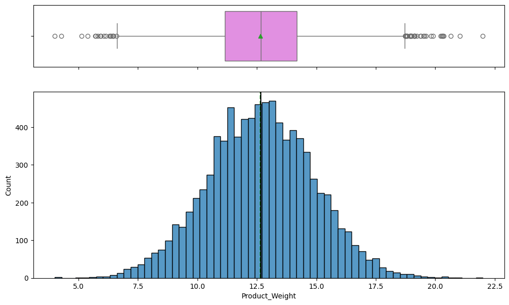

```python
#plotting the histogram for product weight
histogram_boxplot(kart, "Product_Weight")
```

#### Observation -

- Upon observation, product weight is equally distributed. Mean and median are almost same.
- There are outliers on the both sides. We will no treat those outliers as product weight can be very low and very high depending on the product type.

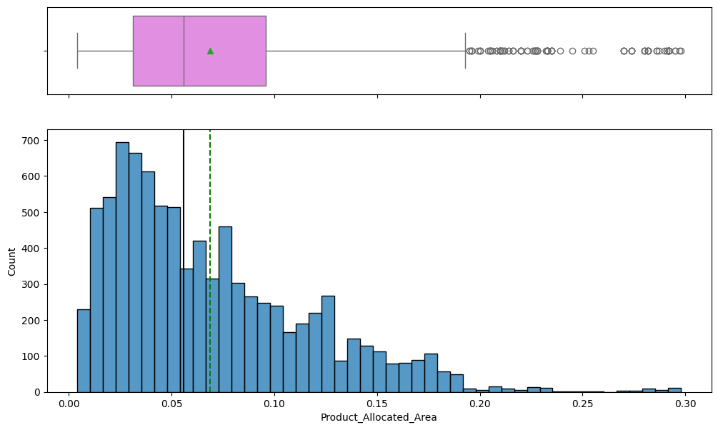

```python
#plotting the histogram for Product_Allocated_Area
histogram_boxplot(kart, "Product_Allocated_Area")
```

#### Observation -

Upon observation, we can safely say product allocated area is right skewed. There are some outliers as well. There are some products who needs more space for the display and some requires less space. So we will not treat outliers.

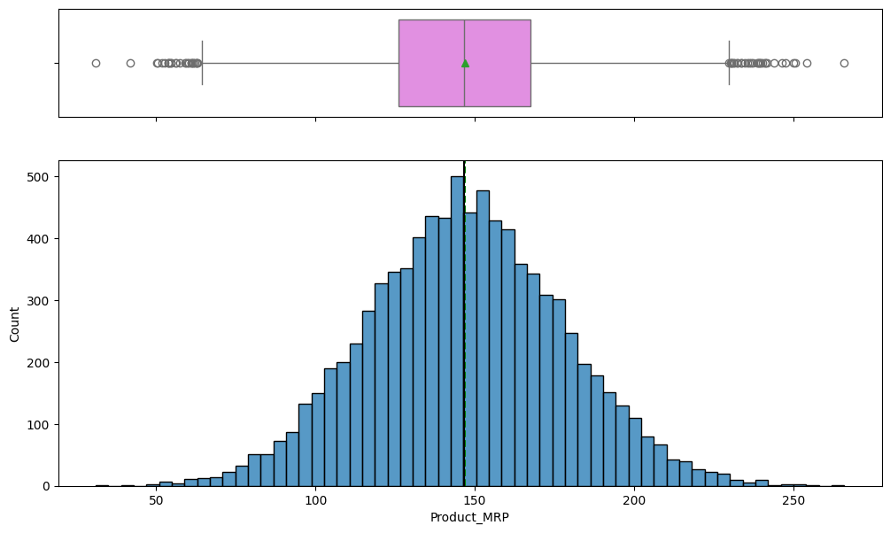

```python
#plotting the histogram for the Product_MRP
histogram_boxplot(kart, "Product_MRP")
```

#### Observation -

- We have outliers on both low and high side of the product price. Product price vary based on the product type. So no outliers will be treated over here.
- Data is equally distributed, mean and median are almost same.

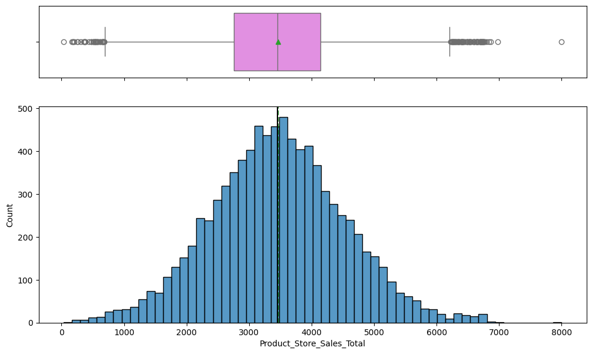

```python
#plotting the histogram for Product_Store_Sales_Total
histogram_boxplot(kart, "Product_Store_Sales_Total")
```

#### Observation -

- Mean and Median of the product store sales are almost same. Also hisplot and box plot shows that data is equally distributed.
- Data has outliers on both low and high side.

```python
#product sugar count
kart['Product_Sugar_Content'].value_counts()
```

| Product_Sugar_Content | count |
| --- | --- |
| Low Sugar | 4885 |
| Regular | 2359 |
| No Sugar | 1519 |

**dtype:** int64

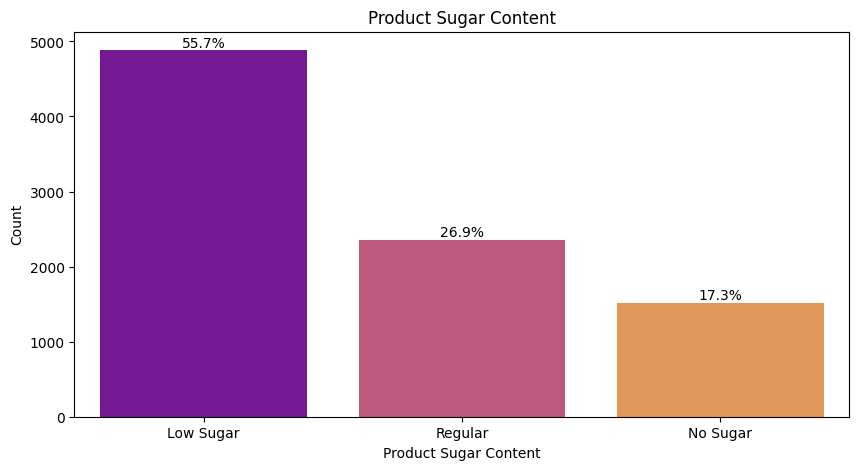

```python
#plotting the bar plot for the product sugar content
plt.figure(figsize=(10, 5))
plt.title('Product Sugar Content')
ax1=sns.countplot(data=kart, x="Product_Sugar_Content",palette='plasma');
plt.xlabel('Product Sugar Content')
plt.ylabel('Count')

total = len(kart['Product_Sugar_Content'])
for p in ax1.patches:
    percentage = '{:.1f}%'.format(100 * p.get_height()/total)
    x = p.get_x() + p.get_width() / 2
    y = p.get_height()
    ax1.annotate(percentage, (x, y), ha='center', va='bottom')

plt.show()
```

#### Observation -

- Almost 56% of the product present in the store are low sugar.
- 26% product have regular sugar and 17% product have no sugar.
- It means store is not carrying any product whose sugar content is very high.

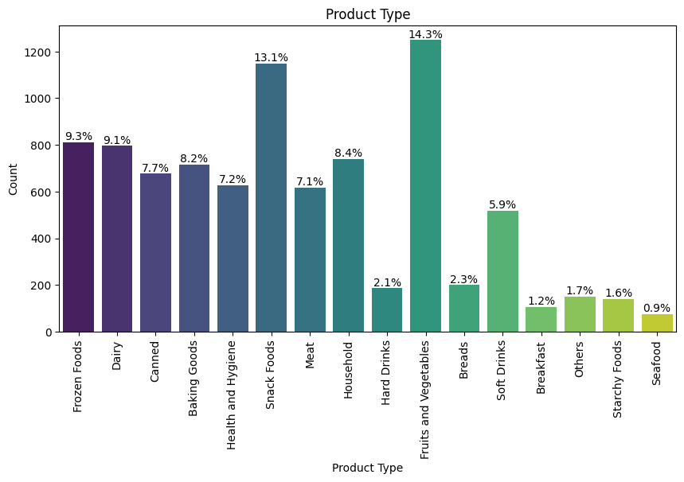

```python
#plotting the bar plot for the product type
plt.figure(figsize=(10, 5))
plt.title('Product Type')
plt.xticks(rotation=90)
ax2=sns.countplot(data=kart, x="Product_Type",palette='viridis');
plt.xlabel('Product Type')
plt.ylabel('Count')

total = len(kart['Product_Type'])
for p in ax2.patches:
    percentage = '{:.1f}%'.format(100 * p.get_height()/total)
    x = p.get_x() + p.get_width() / 2
    y = p.get_height()
    ax2.annotate(percentage, (x, y), ha='center', va='bottom')

plt.show()
```

#### Observation -

- Store is carrying variety of foods like vegetables, fruits, canned food, baked food etc.
- Fruits and vegetable products are highest followed by the snack food is present in the store.
- Store carries few of these products. They are seafood, starchy food, hard drinks, breads, breakfast, etc.

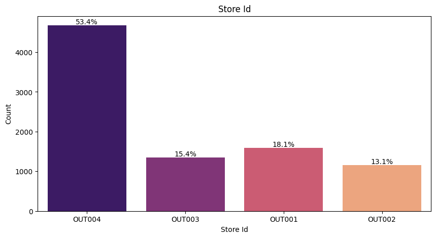

```python
#plotting the bar plot for the Store Id
plt.figure(figsize=(10, 5))
plt.title('Store Id')
ax3=sns.countplot(data=kart, x="Store_Id",palette='magma');
plt.xlabel('Store Id')
plt.ylabel('Count')

total = len(kart['Store_Id'])
for p in ax3.patches:
    percentage = '{:.1f}%'.format(100 * p.get_height()/total)
    x = p.get_x() + p.get_width() / 2
    y = p.get_height()
    ax3.annotate(percentage, (x, y), ha='center', va='bottom')

plt.show()
```

#### Observation -

- The bar plot shows that `OUT004` accounts for a significant proportion (53%) of the product entries, making it the most represented store in the dataset. This indicates an imbalanced distribution of products across `Store_Id`s, with `OUT004` being dominant, rather than an equal distribution. The remaining stores share the remaining percentage.

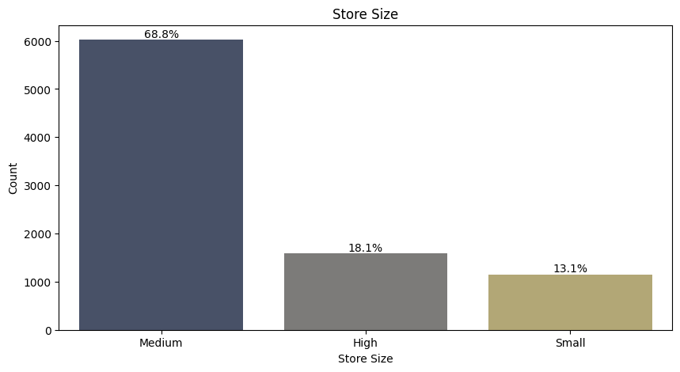

```python
#plotting the bar plot for the Store Size
plt.figure(figsize=(10, 5))
plt.title('Store Size')
ax4=sns.countplot(data=kart, x="Store_Size",palette='cividis');
plt.xlabel('Store Size')
plt.ylabel('Count')

total = len(kart['Store_Size'])
for p in ax4.patches:
    percentage = '{:.1f}%'.format(100 * p.get_height()/total)
    x = p.get_x() + p.get_width() / 2
    y = p.get_height()
    ax4.annotate(percentage, (x, y), ha='center', va='bottom')

plt.show()
```

#### Observation -

- Almost 70% of the stores are of medium size.
- Followed by the high size and remaining as small size.

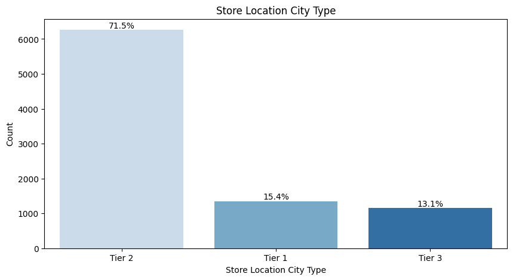

```python
#plotting the bar plot for the Store Location City Type
plt.figure(figsize=(10, 5))
plt.title('Store Location City Type')
ax5=sns.countplot(data=kart, x="Store_Location_City_Type",palette='Blues');
plt.xlabel('Store Location City Type')
plt.ylabel('Count')

total = len(kart['Store_Location_City_Type'])
for p in ax5.patches:
    percentage = '{:.1f}%'.format(100 * p.get_height()/total)
    x = p.get_x() + p.get_width() / 2
    y = p.get_height()
    ax5.annotate(percentage, (x, y), ha='center', va='bottom')

plt.show()
```

#### Observation -

- Tier 2 location have 72% of the store.
- Followed by tier 1 and tier 3 location.

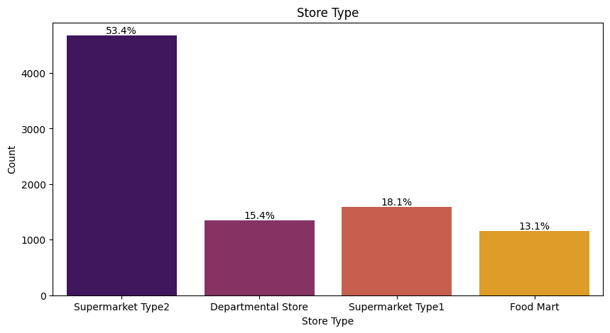

```python
#plotting the bar plot for the Store Type
plt.figure(figsize=(10, 5))
plt.title('Store Type')
ax6 = sns.countplot(data=kart, x="Store_Type",palette='inferno');
plt.xlabel('Store Type')
plt.ylabel('Count')

total = len(kart['Store_Type'])
for p in ax6.patches:
    percentage = '{:.1f}%'.format(100 * p.get_height()/total)
    x = p.get_x() + p.get_width() / 2
    y = p.get_height()
    ax6.annotate(percentage, (x, y), ha='center', va='bottom')
plt.show()
```

#### Observation -

- 53% of the number of the stores are supermarket type2.
- Followed by supermarket type1, departmental store and rest of them are food mart.

## Bivariate Analysis

##### Correlation Matrix

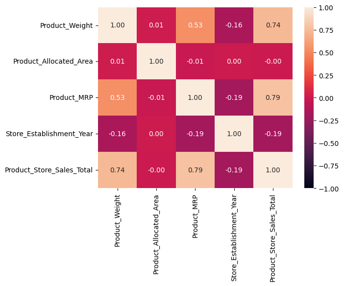

```python
#correlation matrix
sns.heatmap(kart.corr(numeric_only=True),annot=True,vmin=-1, vmax=1, fmt=".2f");
```

#### Observation -

- Target variable product store sales total is affected by the product weight and product price in positive way. If product weight and its price increases, it increases product sales total.
- Product price and product weight are also coupled in positive way.
- Product display area and store establishment year doesn't have much effect on store sales.

#### Distribution of Product_Store_Sales_Total with other numeric columns

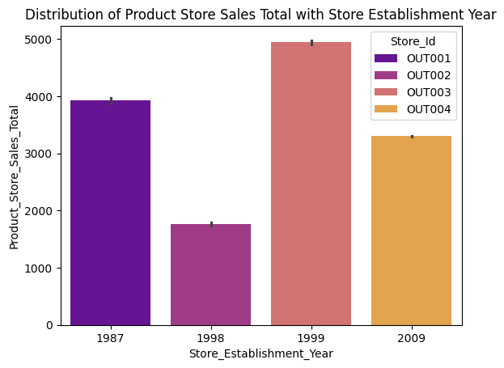

```python
#distribution of Product store sales total with store establishment year
sns.barplot(x='Store_Establishment_Year', y='Product_Store_Sales_Total', data=kart,palette='plasma',hue='Store_Id');
plt.title('Distribution of Product Store Sales Total with Store Establishment Year');
plt.show()
```

#### Observation -

- Oldest store OUT001 was established in year 1987 and and youngest store OUT004 is established in year 2009.

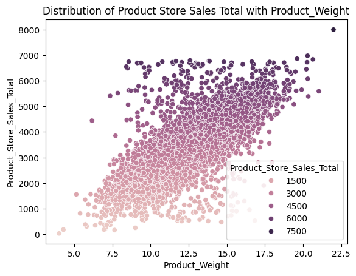

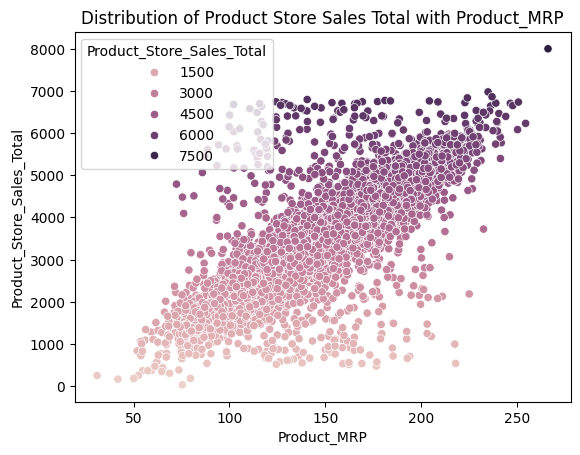

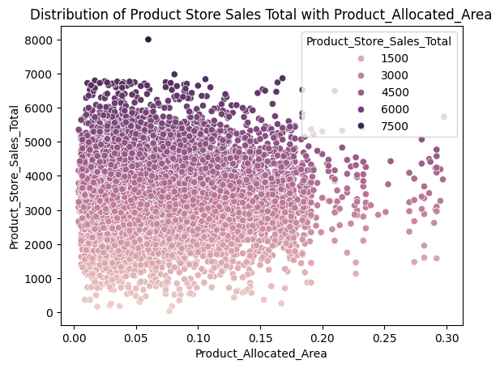

```python
#distribution of product_store_sales_total with other numeric columns
cols_numeric = ['Product_Weight', 'Product_MRP', 'Product_Allocated_Area']
for i in cols_numeric:
  sns.scatterplot(x=i,y='Product_Store_Sales_Total', data=kart,hue='Product_Store_Sales_Total');
  plt.title(f'Distribution of Product Store Sales Total with {i}');
  plt.show()
```

#### Observation -

##### Product type from which company generates most revenue

```python
#type of the product which generates most revenue for the company
revenue_product = kart.groupby('Product_Type')['Product_Store_Sales_Total'].sum().sort_values(ascending=False)
print(revenue_product)
```

```
Product_Type
Fruits and Vegetables    4300833.27
Snack Foods              3988996.95
Dairy                    2811918.04
Frozen Foods             2809980.83
Household                2564740.17
Baking Goods             2452986.00
Canned                   2300082.71
Health and Hygiene       2163707.21
Meat                     2129211.94
Soft Drinks              1797044.72
Breads                    714942.24
Hard Drinks               625814.62
Others                    541496.30
Starchy Foods             518774.45
Breakfast                 362130.41
Seafood                   272404.04
Name: Product_Store_Sales_Total, dtype: float64
```

#### Observation -

- Based on the product type which is generating the maximum revenue is fruits and vegetables followed by the snack food and dairy.
- Least revenue generating product type is seafood.

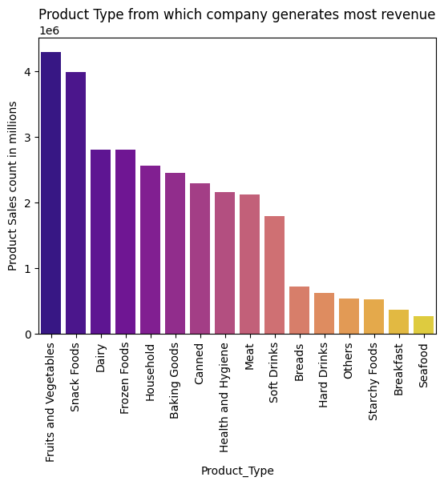

```python
#plotting a barplot showing the product type which generates most revenue
sns.barplot(x=revenue_product.index, y=revenue_product.values, palette='plasma');
plt.title('Product Type from which company generates most revenue')
x_labels=plt.xticks(rotation=90)
plt.ylabel("Product Sales count in millions")
plt.show()
```

#### Observation -

- As mentioned above fruits and vegetables is highest revenue generating category and seafood is least revenue generating category.

#### Most revenue generating product by sugar content

```python
#displaying sugar content and there corresponding revenue
revenue_sugar = kart.groupby('Product_Sugar_Content')['Product_Store_Sales_Total'].sum().sort_values(ascending=False)
print(revenue_sugar)
```

```
Product_Sugar_Content
Low Sugar    16823405.80
Regular       8261714.42
No Sugar      5269943.68
Name: Product_Store_Sales_Total, dtype: float64
```

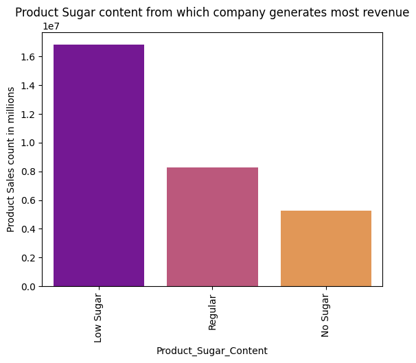

```python
#plotting the bar graph showing the revenue generated by sugar content product
sns.barplot(x=revenue_sugar.index, y=revenue_sugar.values, palette='plasma');
plt.title('Product Sugar content from which company generates most revenue')
x_labels=plt.xticks(rotation=90)
plt.ylabel("Product Sales count in millions")
plt.show()
```

#### Observation -

- Low sugar product are generating the highest revenue.
- No sugar category is least revenue generating category.

#### Stores and location which generates most revenues

```python
#stores which generates highest revenue
revenue_store = kart.groupby('Store_Id')['Product_Store_Sales_Total'].sum().sort_values(ascending=False)
print(revenue_store)
```

```
Store_Id
OUT004    15427583.43
OUT003     6673457.57
OUT001     6223113.18
OUT002     2030909.72
Name: Product_Store_Sales_Total, dtype: float64
```

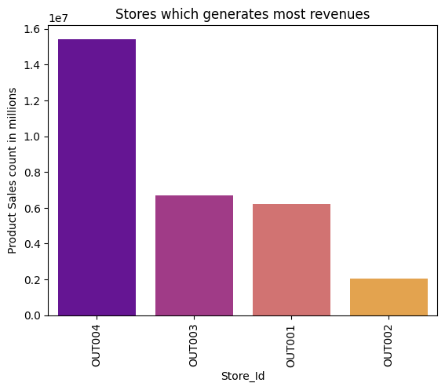

```python
#plotting graph
sns.barplot(x=revenue_store.index, y=revenue_store.values, palette='plasma');
plt.title('Stores which generates most revenues')
x_labels=plt.xticks(rotation=90)
plt.ylabel("Product Sales count in millions")
plt.show()
```

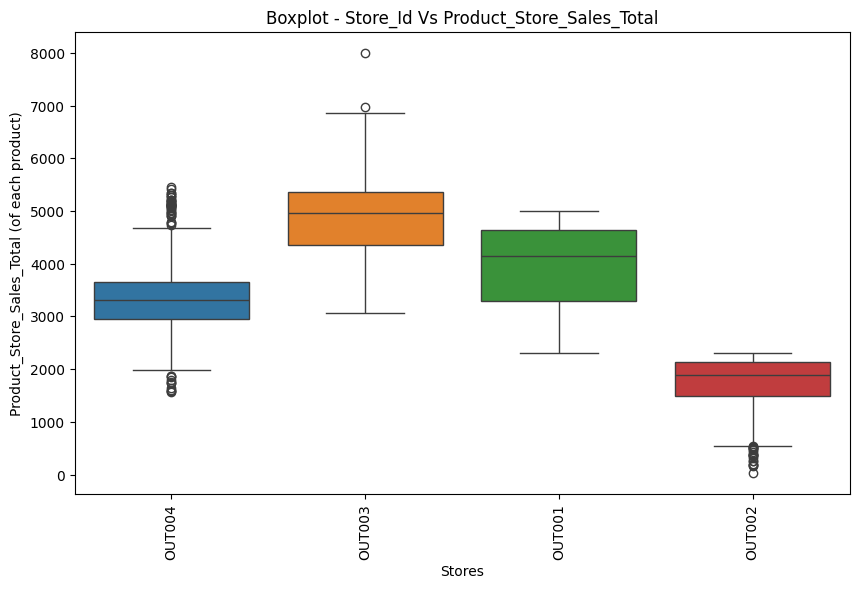

```python
#box plot of the store id and product store sales total
plt.figure(figsize=[10, 6])
sns.boxplot(data=kart, x="Store_Id", y="Product_Store_Sales_Total", hue = "Store_Id")
plt.xticks(rotation=90)
plt.title("Boxplot - Store_Id Vs Product_Store_Sales_Total")
plt.xlabel("Stores")
plt.ylabel("Product_Store_Sales_Total (of each product)")
plt.show()
```

```python
#location which generates most revenue
revenue_location = kart.groupby('Store_Location_City_Type')['Product_Store_Sales_Total'].sum().sort_values(ascending=False)
print(revenue_location)
```

```
Store_Location_City_Type
Tier 2    21650696.61
Tier 1     6673457.57
Tier 3     2030909.72
Name: Product_Store_Sales_Total, dtype: float64
```

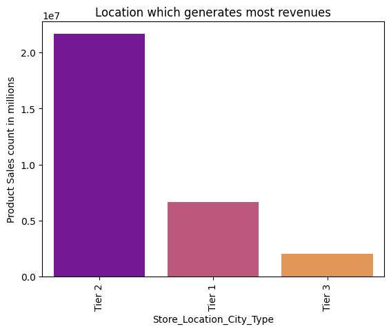

```python
#plotting the graph for the location which generates most revenue,hue='Store_Id'
sns.barplot(x=revenue_location.index, y=revenue_location.values, palette='plasma');
plt.title('Location which generates most revenues')
x_labels=plt.xticks(rotation=90)
plt.ylabel("Product Sales count in millions")
plt.show()
```

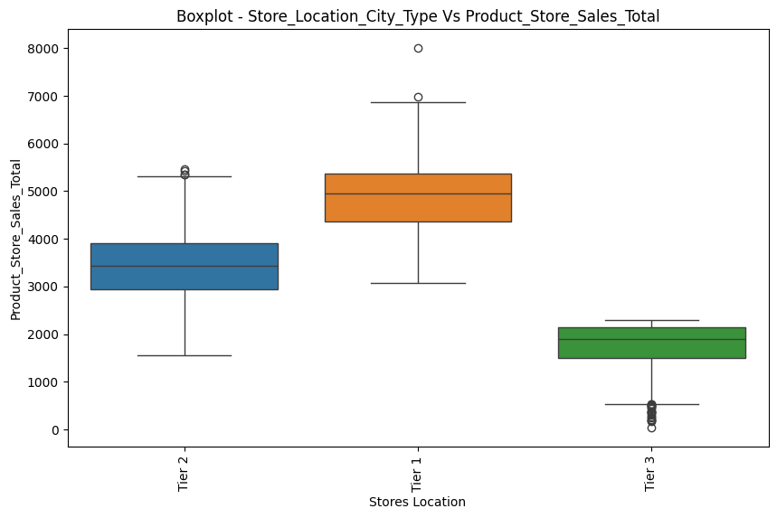

```python
#box plot of the store location and product store sales total
plt.figure(figsize=[10, 6])
sns.boxplot(data=kart, x="Store_Location_City_Type", y="Product_Store_Sales_Total", hue = "Store_Location_City_Type")
plt.xticks(rotation=90)
plt.title("Boxplot - Store_Location_City_Type Vs Product_Store_Sales_Total")
plt.xlabel("Stores Location")
plt.ylabel("Product_Store_Sales_Total")
plt.show()
```

#### Observation -

- Tier 2 store location generates highest revenue.
- But median value of the tier 1 location is highest among all 3 locations which indicates high value items are sold in this location.
- Tier 3 revenue generation is least. It alos have outliers in the lower side which indicates low value items are being sold in this store.

#### Store ID's location and size details

```python
#to find which store id in which store location
kart.groupby(['Store_Id','Store_Size','Store_Type','Store_Location_City_Type']).size()
```

| Store_Id | Store_Size | Store_Type | Store_Location_City_Type | 0 |
| --- | --- | --- | --- | --- |
| OUT001 | High | Supermarket Type1 | Tier 2 | 1586 |
| OUT002 | Small | Food Mart | Tier 3 | 1152 |
| OUT003 | Medium | Departmental Store | Tier 1 | 1349 |
| OUT004 | Medium | Supermarket Type2 | Tier 2 | 4676 |

**dtype:** int64

#### Observation -

- OUT004 and OUT001 are located in Tier 2 location but OUT004 is medium size store but highest revenue whereas OUT001 is high size store but revenue is less as far as size is concerned.
- OUT002 is located in Tier 3 location and it is least performing the store and it is small store so less revenue.
- OUT003 is located in Tier1 location but its 2nd best performance and again it is medium size store.
- It seems OUT004 is medium size and Tier 2 location are contributing factors in OUT004 success.

```python
#Store size relation with the product sales
revenue_size = kart.groupby('Store_Size')['Product_Store_Sales_Total'].sum().sort_values(ascending=False)
print(revenue_size)
```

```
Store_Size
Medium    22101041.00
High       6223113.18
Small      2030909.72
Name: Product_Store_Sales_Total, dtype: float64
```

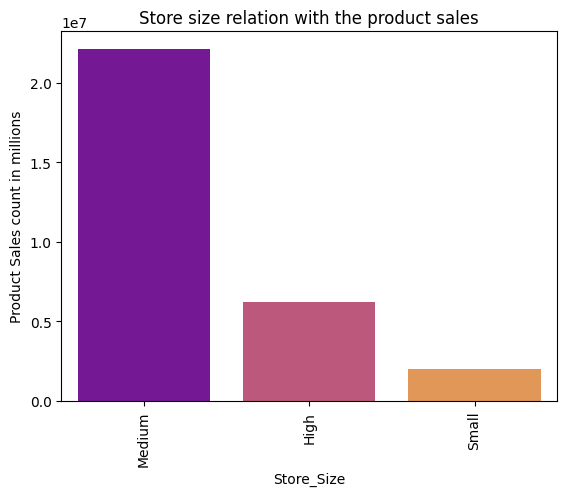

```python
#plotting the graph for store size and product sales revenue
sns.barplot(x=revenue_size.index, y=revenue_size.values, palette='plasma');
plt.title('Store size relation with the product sales')
x_labels=plt.xticks(rotation=90)
plt.ylabel("Product Sales count in millions")
plt.show()
```

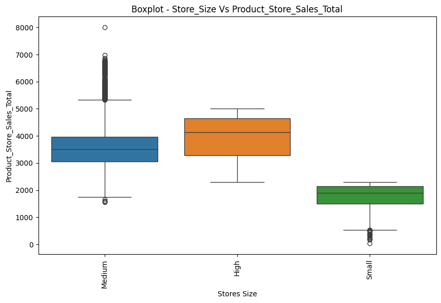

```python
#box plot of the store size and product store sales total
plt.figure(figsize=[10, 6])
sns.boxplot(data=kart, x="Store_Size", y="Product_Store_Sales_Total", hue = "Store_Size")
plt.xticks(rotation=90)
plt.title("Boxplot - Store_Size Vs Product_Store_Sales_Total")
plt.xlabel("Stores Size")
plt.ylabel("Product_Store_Sales_Total")
plt.show()
```

- Medium size store are highest and most revenue generated store. OUT004 and OUT003 are tier 2 and tier 1 stores where OUT004 and OUT003 are highest revenue generative store.
- High size store is OUT001 store in tier 2 location.
- Small size store is OUT002 and in tier 3 location with small revenue.

```python
#Store type and product sales
revenue_type = kart.groupby('Store_Type')['Product_Store_Sales_Total'].sum().sort_values(ascending=False)
print(revenue_type)
```

```
Store_Type
Supermarket Type2     15427583.43
Departmental Store     6673457.57
Supermarket Type1      6223113.18
Food Mart              2030909.72
Name: Product_Store_Sales_Total, dtype: float64
```

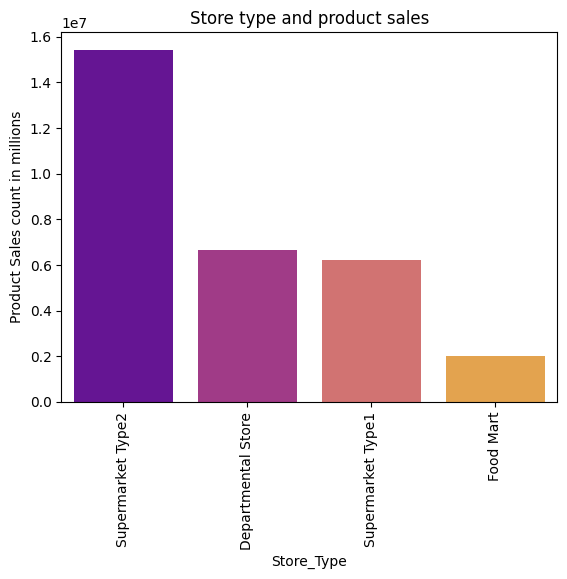

```python
#plotting the graph between store type and product store sales
sns.barplot(x=revenue_type.index, y=revenue_type.values, palette='plasma');
plt.title('Store type and product sales')
x_labels=plt.xticks(rotation=90)
plt.ylabel("Product Sales count in millions")
plt.show()
```

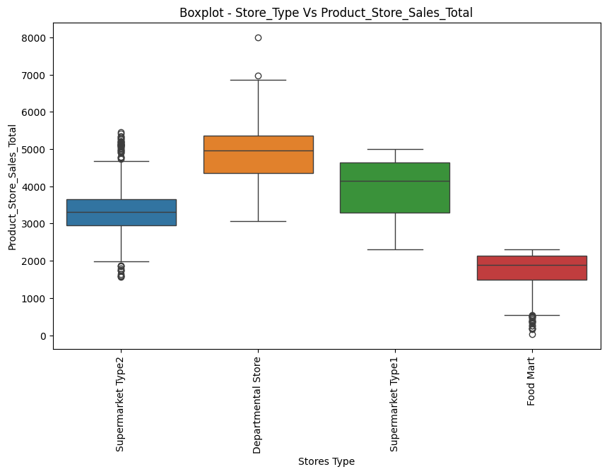

```python
#box plot of the store type and product store sales total
plt.figure(figsize=[10, 6])
sns.boxplot(data=kart, x="Store_Type", y="Product_Store_Sales_Total", hue = "Store_Type")
plt.xticks(rotation=90)
plt.title("Boxplot - Store_Type Vs Product_Store_Sales_Total")
plt.xlabel("Stores Type")
plt.ylabel("Product_Store_Sales_Total")
plt.show()
```

#### Observation -

- Food mart which is store OUT002 have lowest median and lowest revenue which is understandable as it only sells food items and small in size and located in Tier 3 location.
- Departmental store which is store OUT003 is a medium sized store located in Tier 1 location have high median. This location have 2nd best revenue generation.
- Supermarket Type 2 is medium store located in tier 2 location is OUT004. This store generates highest revenue.
- Supermarket type 1 is high store located in tier 2 store and have high median.

#### Relationship between product type and product weight

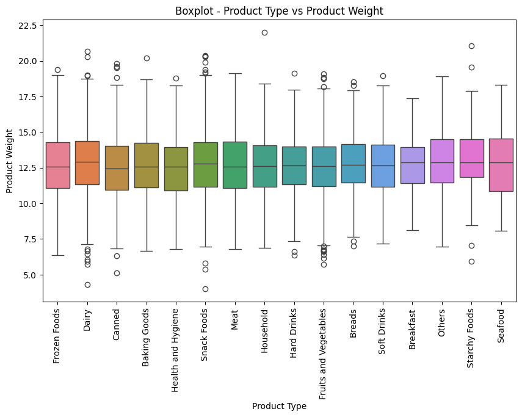

```python
#box plot of the product type and product weight
plt.figure(figsize=[10, 6])
sns.boxplot(data=kart, x="Product_Type", y="Product_Weight", hue = "Product_Type")
plt.xticks(rotation=90)
plt.title("Boxplot - Product Type vs Product Weight")
plt.xlabel("Product Type")
plt.ylabel("Product Weight")
plt.show()
```

#### Observation -

- Box plot shows that median weight of all the products in different category is almost equal. Some categories have outliers which indicates that those proudct categories have some product whose weight is very high or very less.

#### Relationship between Product weight and Product sugar content

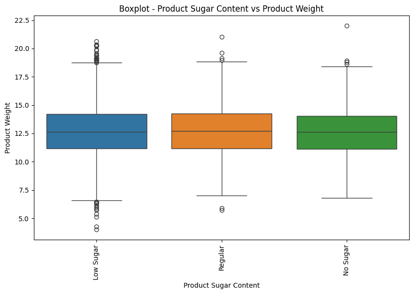

```python
#box plot of the product weight and product sugar content
plt.figure(figsize=[10, 6])
sns.boxplot(data=kart, x="Product_Sugar_Content", y="Product_Weight", hue = "Product_Sugar_Content")
plt.xticks(rotation=90)
plt.title("Boxplot - Product Sugar Content vs Product Weight")
plt.xlabel("Product Sugar Content")
plt.ylabel("Product Weight")
plt.show()
```

#### Observation -

- Median weight of the all the sugar containing product is almost same.
- Low sugar category have some outliers where product weight is either very low or very high.

#### Product Sugar Content and Different Product type

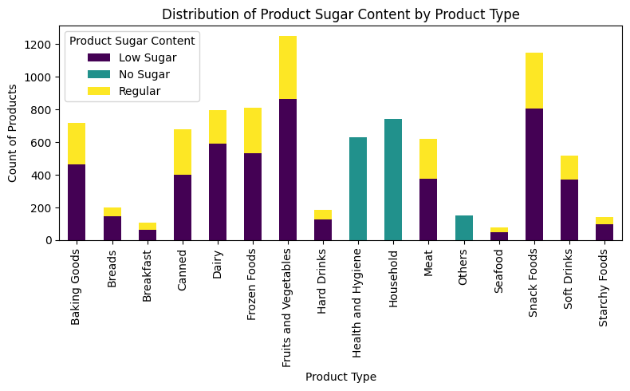

```python
# Create a crosstab for the counts and show the relation between product type and product sugar content
crosstab_data = pd.crosstab(kart["Product_Type"], kart["Product_Sugar_Content"])

# Plotting the stacked bar chart
crosstab_data.plot(kind='bar', stacked=True, figsize=(8, 5), cmap='viridis')
plt.title('Distribution of Product Sugar Content by Product Type')
plt.xlabel('Product Type')
plt.ylabel('Count of Products')
plt.xticks(rotation=90)
plt.legend(title='Product Sugar Content')
plt.tight_layout()
plt.show()
```

#### How many items of each product type has been sold in each of the stores

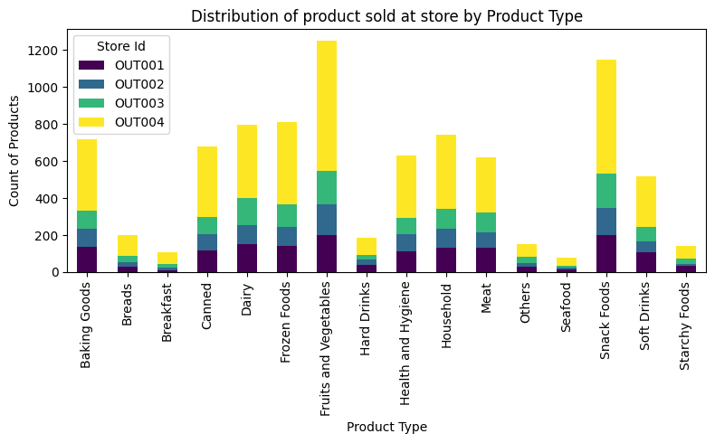

```python
crosstab_data = pd.crosstab(kart["Product_Type"], kart["Store_Id"])

# Plotting the stacked bar chart
crosstab_data.plot(kind='bar', stacked=True, figsize=(8, 5), cmap='viridis')
plt.title('Distribution of product sold at store by Product Type')
plt.xlabel('Product Type')
plt.ylabel('Count of Products')
plt.xticks(rotation=90)
plt.legend(title='Store Id')
plt.tight_layout()
plt.show()
```

#### Different product types have different prices

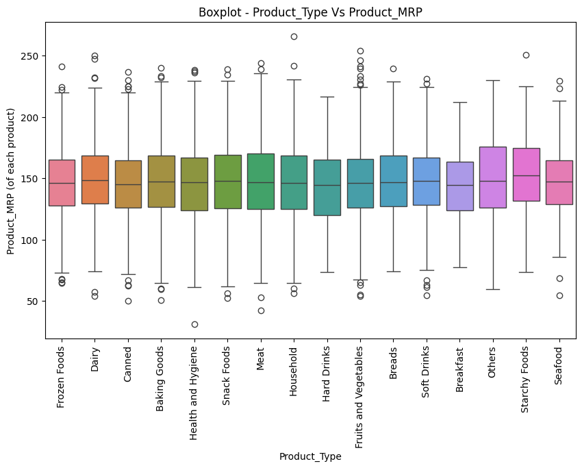

```python
plt.figure(figsize=[10, 6])
sns.boxplot(data = kart, x = "Product_Type", y = "Product_MRP", hue = "Product_Type")
plt.xticks(rotation=90)
plt.title("Boxplot - Product_Type Vs Product_MRP")
plt.xlabel("Product_Type")
plt.ylabel("Product_MRP (of each product)")
plt.show()
```

#### Observation -

- Median price of different products in different product category doesnt show much variation.
- We have some outliers in almost all the product categories which shows that some products have high prices.

#### Product MRP with different store

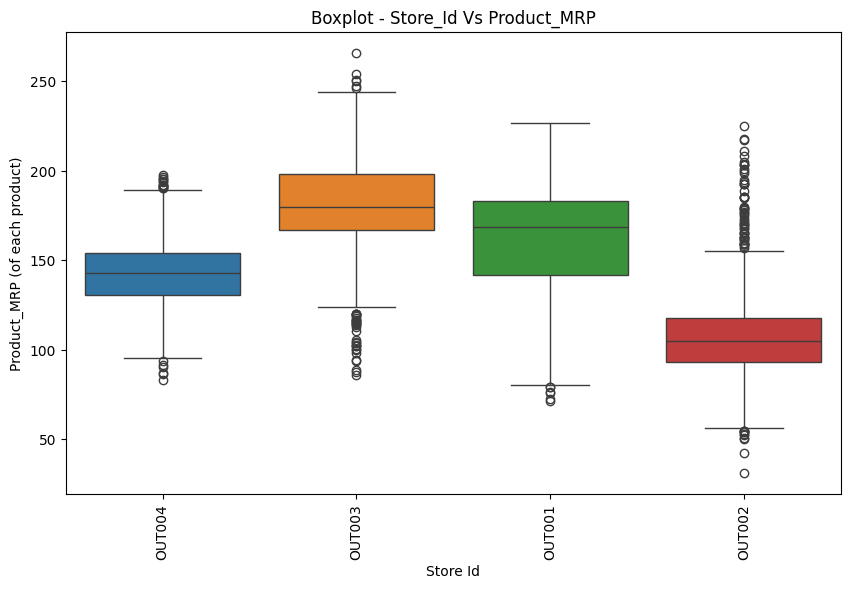

```python
plt.figure(figsize=[10, 6])
sns.boxplot(data = kart, x = "Store_Id", y = "Product_MRP", hue = "Store_Id")
plt.xticks(rotation=90)
plt.title("Boxplot - Store_Id Vs Product_MRP")
plt.xlabel("Store Id")
plt.ylabel("Product_MRP (of each product)")
plt.show()
```

#### Observation -

- OUT003 have highest median which shows that this store sells high value items.
- OUT002 have lowest median and outliers on the lower side shows that this store have low value items.